# Pruebas Raiz unitaria

Miguel G.

17/3/2022

```r
# limpiar ambiente de trabajo
rm(list=ls())

# Directorio de trabajo
setwd("C:/Users/Miike/Desktop/Pronosticos/raiz_unitaria")

library(readxl)
library(tseries)

# Cargar datos 3 series de tiempo

pib <- read_excel("pruebas_raiz.xlsx", sheet="us_pib")

ventas <- read_excel("pruebas_raiz.xlsx", sheet="ventas_papel")

quimico <- read_excel("pruebas_raiz.xlsx", sheet="quimico")
```

# Serie del PIB

Necesito identificar si la serie del PIB de Estados Unidos es estacionaria o no, si no lo es, necesito identificar el grado de integración, es decir, cuantas veces debo diferenciarla para que sea estacionaria

Declarar como serie de tiempo:

```r
us_pib <- ts(pib$ln_gdp, start = c(1952,1), frequency = 4 )
```

Grafica de la serie:

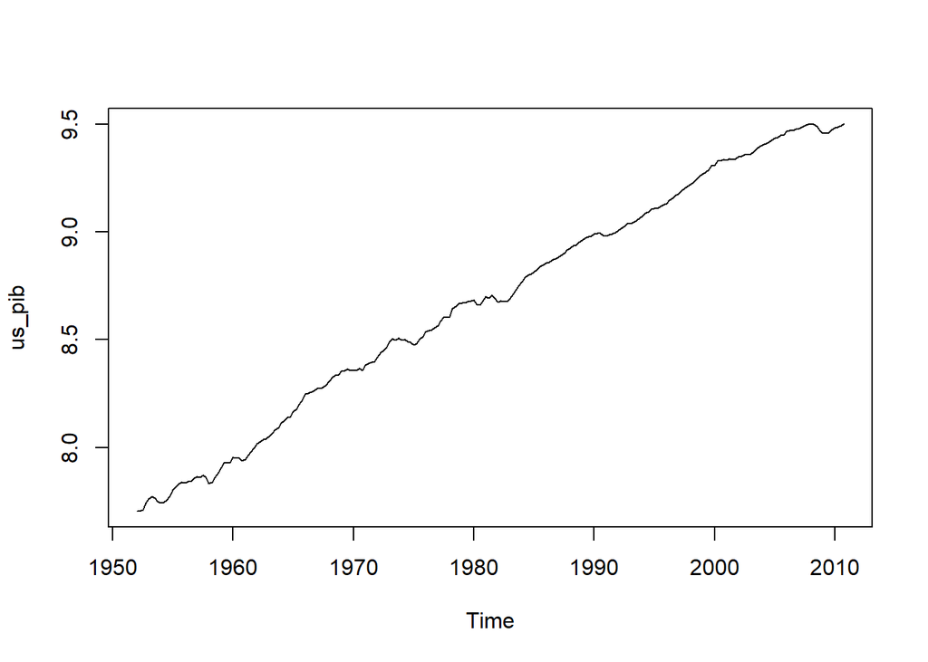

```r
ts.plot(us_pib)
```

```r
adf.test(us_pib)
```

```
##
##  Augmented Dickey-Fuller Test
##
## data:  us_pib
## Dickey-Fuller = -1.33, Lag order = 6, p-value = 0.8575
## alternative hypothesis: stationary
```

No puedo rechazar la hipótesis nula, la serie del PIB de USA, NO es estacionaria

Necesito calcular las primeras diferencias para ver si es estacionaria

```r
adf.test(diff(us_pib))
```

```
##
##  Augmented Dickey-Fuller Test
##
## data:  diff(us_pib)
## Dickey-Fuller = -6.0406, Lag order = 6, p-value = 0.01
## alternative hypothesis: stationary
```

rechazo Ho, existe evidencia de que las primeras diferencias de la serie del PIB es estacionaria, es decir, la serie del PIB es integrada de orden 1.

# Serie de ventas

Declarar como serie de tiempo las ventas de papel de la empresa

```r
papel <- ts(ventas$ventas, start = c(2000,1), frequency = 12)
```

Grafica de la serie

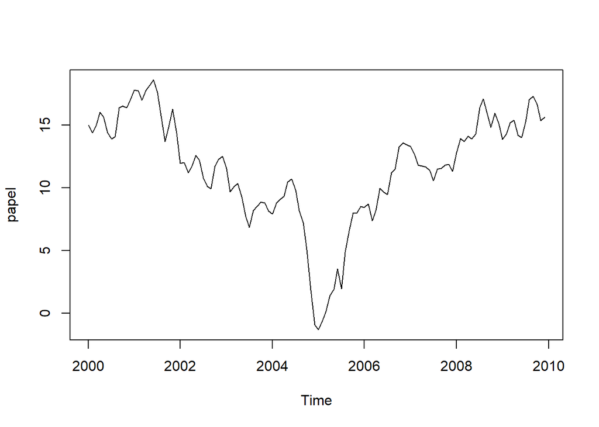

```r
ts.plot(papel)
```

```r
adf.test(papel)
```

```
##
##  Augmented Dickey-Fuller Test
##
## data:  papel
## Dickey-Fuller = -1.7786, Lag order = 4, p-value = 0.6685
## alternative hypothesis: stationary
```

La serie de ventas de papel no es estacionaria

```r
adf.test(diff(papel))
```

```
##
##  Augmented Dickey-Fuller Test
##
## data:  diff(papel)
## Dickey-Fuller = -4.2053, Lag order = 4, p-value = 0.01
## alternative hypothesis: stationary
```

Las ventas de papel son integradas de orden 1, es decir, necesito diferenciarlas una vez para que la serie sea estacionaria

# Viscosidad de un quimico

Declarar como serie de tiempo:

```r
viscosidad <- ts(quimico$viscosidad, start = c(2000,1) , frequency = 52)
```

Gráfica de la serie:

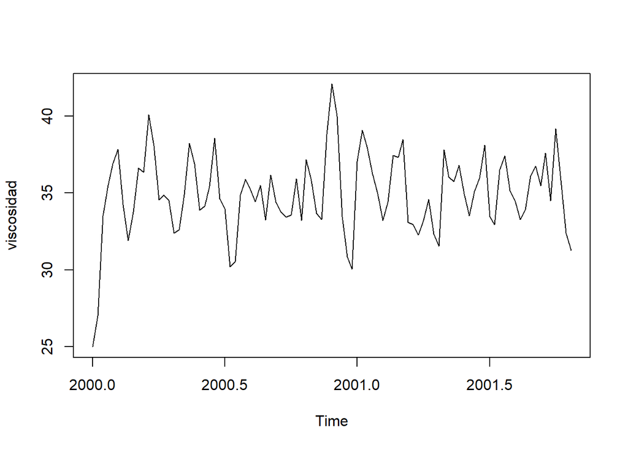

```r
ts.plot(viscosidad)
```

```r
adf.test(viscosidad)
```

```
##
##  Augmented Dickey-Fuller Test
##
## data:  viscosidad
## Dickey-Fuller = -5.1949, Lag order = 4, p-value = 0.01
## alternative hypothesis: stationary
```

La serie de viscosidad es estacionaria desde el inicio, es decir,es integrada de orden 0